# Notebook

## Introduction

Welcome to the second installment of my data expert role-play series in the iGaming industry. In this article, we'll explore building a predictive model to evaluate bonus requests from VIP segment personal consultants. The model will analyze historical data to determine whether bonus requests should be approved.

## Objective

Build a predictive model that:

- Evaluates bonus requests from VIP personal consultants
- Determines approval eligibility based on historical patterns
- Provides data-driven decision support for bonus allocation

## Data Description

Dataset: `bonus_request_dataset.csv`

### Key Features:

**User Profile:**

- `person_age`
- `annual_deposit_amount`
- `tier_segment_duration`
- `current_segment_tier`

**Bonus Request Details:**

- `requested_bonus_type`
- `requested_bonus_value`
- `bonus_wagering_requirement`

**Behavioral & Historical Factors:**

- `preferred_game_category`
- `bonus_hist_length`
- `previous_segment_downgrade`

**Target Variable:**

- `bonus_status` (Approved/Rejected)

## Feature Engineering

- Process numerical and categorical features separately
- Handle missing values appropriately
- Encode categorical features using `OneHotEncoder`

## Model Training

- Implement `XGBClassifier` (XGBoost) as primary model
- Conduct hyperparameter tuning with `HalvingGridSearchCV`
- Optimize key parameters: `learning_rate` and `max_depth`

## Evaluation

- Assess model using cross-validation
- Measure accuracy metrics
- Final testing on holdout dataset

## Visualization

- Generate heatmaps for correlation analysis
- Create count plots for categorical distributions
- Plot feature distributions

## POC Implementation

- Test model with randomized customer profiles
- Validate real-world applicability

```python
import numpy as np # linear algebra
import pandas as pd # data processing, CSV file I/O (e.g. pd.read_csv)
from sklearn.feature_selection import mutual_info_regression
from sklearn.preprocessing import OneHotEncoder
from sklearn.linear_model import LogisticRegression
from sklearn.model_selection import train_test_split
import sklearn.metrics as sm
from sklearn.ensemble import RandomForestClassifier
from xgboost import XGBClassifier
from sklearn.linear_model import RidgeClassifier
from sklearn.pipeline import Pipeline
from sklearn.impute import SimpleImputer
from sklearn.model_selection import cross_val_score
from sklearn.compose import ColumnTransformer
from sklearn.model_selection import GridSearchCV
from sklearn.metrics import accuracy_score
import matplotlib.pyplot as plt
from plotly.offline import init_notebook_mode
init_notebook_mode(connected=True)
```

```python
df = pd.read_csv("C:/Users/Memre/Documents/GitHub/EmreToktay.github.io/blogpost/bonus_request_dataset.csv")
```

```python
df
```

|  | person_age | annual_deposit_amount | preferred_game_category | tier_segment_duration | requested_bonus_type | current_segment_tier | requested_bonus_value | bonus_wagering_requirement | bonus_status | bonus_to_deposit_ratio | previous_segment_downgrade | bonus_hist_length |
| --- | --- | --- | --- | --- | --- | --- | --- | --- | --- | --- | --- | --- |
| 0 | 22 | 59000 | CASINO | 123.0 | CASHBACK | D | 35000 | 16.02 | 1 | 0.59 | Y | 3 |
| 1 | 21 | 9600 | BET | 5.0 | FREESPIN | B | 1000 | 11.14 | 0 | 0.10 | N | 2 |
| 2 | 25 | 9600 | LIVECAS | 1.0 | DEPOSIT | C | 5500 | 12.87 | 1 | 0.57 | N | 3 |
| 3 | 23 | 65500 | CASINO | 4.0 | DEPOSIT | C | 35000 | 15.23 | 1 | 0.53 | N | 2 |
| 4 | 24 | 54400 | CASINO | 8.0 | DEPOSIT | C | 35000 | 14.27 | 1 | 0.55 | Y | 4 |
| ... | ... | ... | ... | ... | ... | ... | ... | ... | ... | ... | ... | ... |
| 32576 | 57 | 53000 | LIVECAS | 1.0 | CASHBACK | C | 5800 | 13.16 | 0 | 0.11 | N | 30 |
| 32577 | 54 | 120000 | LIVECAS | 4.0 | CASHBACK | A | 17625 | 7.49 | 0 | 0.15 | N | 19 |
| 32578 | 65 | 76000 | CASINO | 3.0 | LOWWAGERING | B | 35000 | 10.99 | 1 | 0.46 | N | 28 |
| 32579 | 56 | 150000 | LIVECAS | 5.0 | CASHBACK | B | 15000 | 11.48 | 0 | 0.10 | N | 26 |
| 32580 | 66 | 42000 | CASINO | 2.0 | DEPOSIT | B | 6475 | 9.99 | 0 | 0.15 | N | 30 |

32581 rows × 12 columns

```python
df.head()
```

|  | person_age | annual_deposit_amount | preferred_game_category | tier_segment_duration | requested_bonus_type | current_segment_tier | requested_bonus_value | bonus_wagering_requirement | bonus_status | bonus_to_deposit_ratio | previous_segment_downgrade | bonus_hist_length |
| --- | --- | --- | --- | --- | --- | --- | --- | --- | --- | --- | --- | --- |
| 0 | 22 | 59000 | CASINO | 123.0 | CASHBACK | D | 35000 | 16.02 | 1 | 0.59 | Y | 3 |
| 1 | 21 | 9600 | BET | 5.0 | FREESPIN | B | 1000 | 11.14 | 0 | 0.10 | N | 2 |
| 2 | 25 | 9600 | LIVECAS | 1.0 | DEPOSIT | C | 5500 | 12.87 | 1 | 0.57 | N | 3 |
| 3 | 23 | 65500 | CASINO | 4.0 | DEPOSIT | C | 35000 | 15.23 | 1 | 0.53 | N | 2 |
| 4 | 24 | 54400 | CASINO | 8.0 | DEPOSIT | C | 35000 | 14.27 | 1 | 0.55 | Y | 4 |

```python
df.columns
```

```
Index(['person_age', 'annual_deposit_amount', 'preferred_game_category',
       'tier_segment_duration', 'requested_bonus_type', 'current_segment_tier',
       'requested_bonus_value', 'bonus_wagering_requirement', 'bonus_status',
       'bonus_to_deposit_ratio', 'previous_segment_downgrade',
       'bonus_hist_length'],
      dtype='object')
```

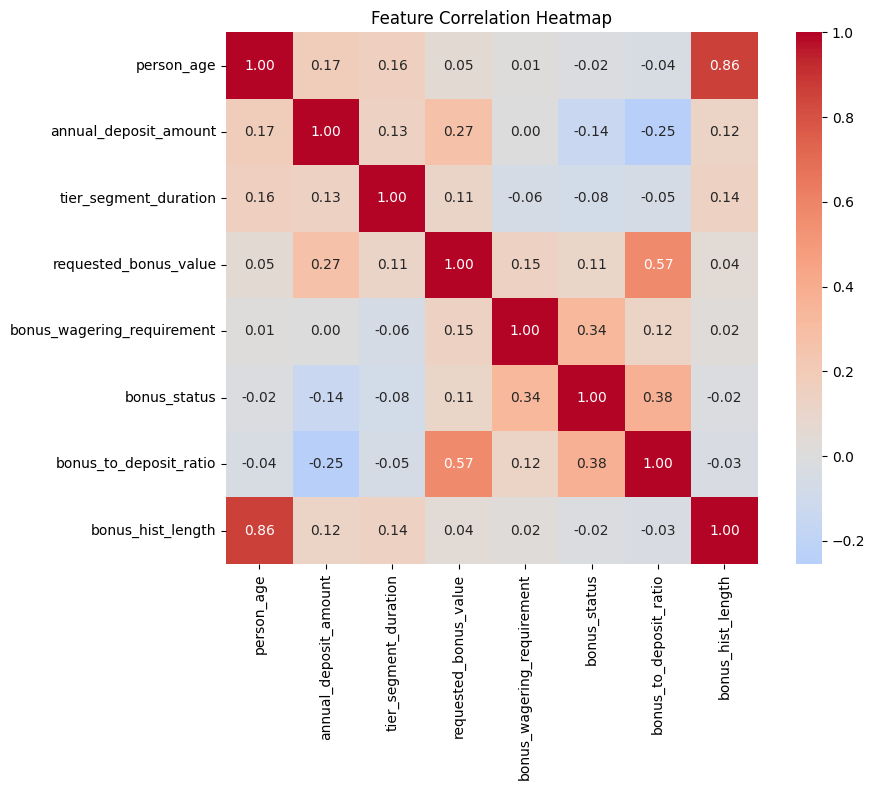

```python
import seaborn as sns
import matplotlib.pyplot as plt

plt.figure(figsize=(10, 8))
corr = df.select_dtypes(include=['number']).corr()
sns.heatmap(corr,
            annot=True,
            fmt=".2f",
            cmap='coolwarm',
            center=0,
            square=True)
plt.title("Feature Correlation Heatmap")
plt.tight_layout()
plt.show()
```

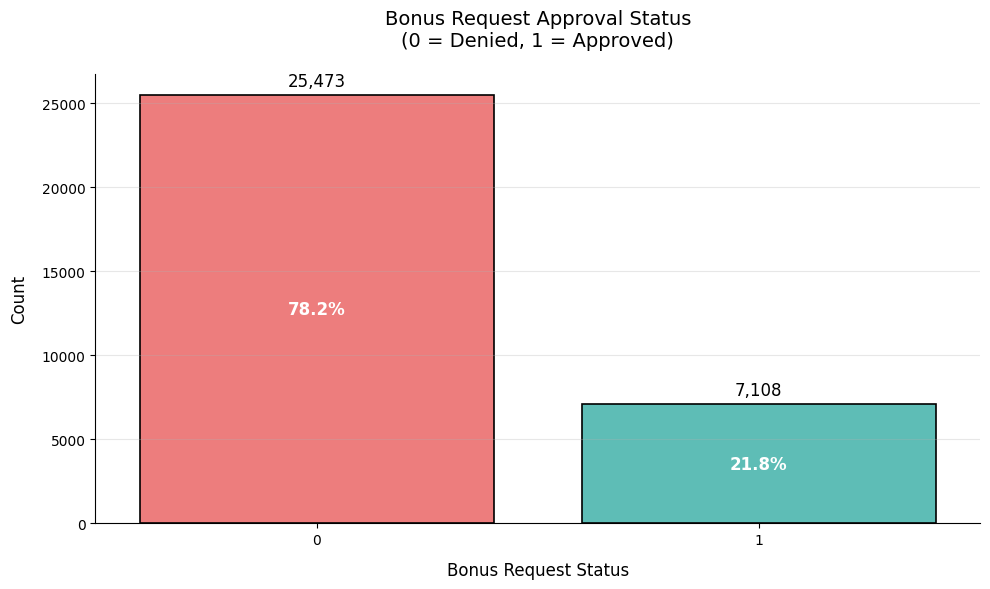

```python
plt.figure(figsize=(10,6))
ax = sns.countplot(x=df["bonus_status"],
                  palette = {'0': "#FF6B6B", '1': "#4ECDC4"} ,  # Red for denied, teal for approved
                  edgecolor="black",
                  linewidth=1.2)

for p in ax.patches:
    ax.annotate(f'{p.get_height():,.0f}',
                (p.get_x() + p.get_width() / 2., p.get_height()),
                ha='center', va='center',
                xytext=(0, 10),
                textcoords='offset points',
                fontsize=12)


plt.xlabel("Bonus Request Status", fontsize=12, labelpad=10)
plt.ylabel("Count", fontsize=12, labelpad=10)
plt.title("Bonus Request Approval Status\n(0 = Denied, 1 = Approved)",
          fontsize=14, pad=20)



plt.grid(axis='y', alpha=0.3)

sns.despine()


total = len(df["bonus_status"])
for p in ax.patches:
    percentage = f'{100 * p.get_height() / total:.1f}%'
    ax.annotate(percentage,
                (p.get_x() + p.get_width() / 2., p.get_height()/2),
                ha='center', va='center',
                color='white',
                fontsize=12,
                fontweight='bold')

plt.tight_layout()
plt.show()
```

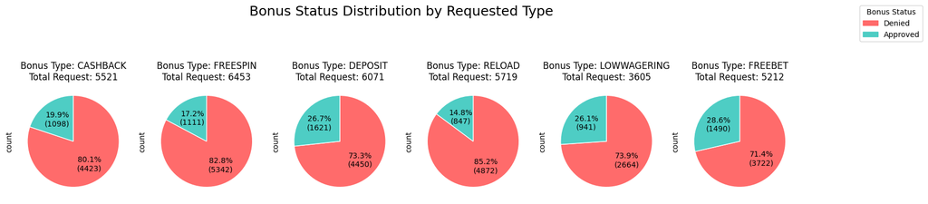

```python
status_colors = {0: '#FF6B6B', 1: '#4ECDC4'}
status_labels = {0: 'Denied', 1: 'Approved'}


fig, axes = plt.subplots(1, len(df['requested_bonus_type'].unique()), figsize=(15,6))

for i, bonus_type in enumerate(df['requested_bonus_type'].unique()):

    counts = df[df['requested_bonus_type'] == bonus_type]['bonus_status'].value_counts()

    pie = counts.plot(
        kind='pie',
        ax=axes[i],
        colors=[status_colors[x] for x in counts.index],
        title=f'Bonus Type: {bonus_type}\nTotal Request: {counts.sum()}',
        autopct=lambda p: f'{p:.1f}%\n({int(round(p*counts.sum()/100))})',
        startangle=90,
        counterclock=False,
        wedgeprops={'linewidth': 1, 'edgecolor': 'white'},
        textprops={'fontsize': 10},
        labels=None
    )

    pie.title.set_position([0.5, 0.95])
    pie.title.set_size(12)

handles = [plt.Rectangle((0,0),1,1, color=status_colors[k], label=status_labels[k])
           for k in status_colors]
fig.legend(handles=handles,
           title='Bonus Status',
           loc='upper right',
           bbox_to_anchor=(1.15, 0.9))

plt.suptitle('Bonus Status Distribution by Requested Type', y=0.89, fontsize=18)
plt.tight_layout()
plt.show()
```

```python
numerical_cols1 = [numname for numname in df.columns if df[numname].dtype in ['int64', 'float64']]
numerical_cols1.remove("bonus_status")
```

```python
import plotly.express as px
import plotly.graph_objects as go
from scipy.stats import gaussian_kde, iqr
import numpy as np
from IPython.display import display
from plotly.offline import init_notebook_mode
init_notebook_mode(connected=True)
for col in numerical_cols1:

    data = df[col].dropna()
    q1 = np.percentile(data, 25)
    q3 = np.percentile(data, 75)
    iqr_val = iqr(data)
    lower_bound = (q1 - 1.5*iqr_val)>0
    upper_bound = q3 + 1.5*iqr_val


    filtered_data = data[(data >= lower_bound) & (data <= upper_bound)]


    fig = px.histogram(filtered_data, x=col, nbins=50,
                      title=f'Distribution of {col} (Outliers Removed)',
                      color_discrete_sequence=['#636EFA'],
                      marginal='box')
    fig.update_layout(bargap=0.1)


    kde = gaussian_kde(filtered_data)
    x_grid = np.linspace(filtered_data.min(), filtered_data.max(), 100)
    kde_vals = kde(x_grid) * len(filtered_data) * (filtered_data.max()-filtered_data.min())/50

    fig.add_trace(go.Scatter(
        x=x_grid,
        y=kde_vals,
        mode='lines',
        name='Density',
        line=dict(color='orange', width=2)
    ))


    skewness = filtered_data.skew()
    fig.add_annotation(
        x=0.95,
        y=0.95,
        xref='paper',
        yref='paper',
        text=f"Skew: {skewness:.2f}",
        showarrow=False,
        bgcolor='white',
        bordercolor='black',
        borderwidth=1
    )


    fig.update_xaxes(range=[lower_bound, upper_bound])



    display(fig)
```

[interactive chart not shown]

```python
#Splitting Dataset
x = df.drop("bonus_status", axis=1)
y = df.bonus_status
X_train, x_test, y_train, y_test = train_test_split(x, y, test_size=0.2)
```

```python
X_train.isnull().sum()
x_test.isnull().sum()
```

```
person_age                      0
annual_deposit_amount           0
preferred_game_category         0
tier_segment_duration         171
requested_bonus_type            0
current_segment_tier            0
requested_bonus_value           0
bonus_wagering_requirement    633
bonus_to_deposit_ratio          0
previous_segment_downgrade      0
bonus_hist_length               0
dtype: int64
```

```python
for colname in x.select_dtypes("object"):
    x[colname], _ = x[colname].factorize()
discrete_features = x.dtypes == int

def make_mi_scores(x, y, discrete_features):
    mi_scores = mutual_info_regression(x, y, discrete_features=discrete_features)
    mi_scores = pd.Series(mi_scores, name="MI Scores", index=x.columns)
```

```python
#preprocessing
numerical_transformer = SimpleImputer(strategy='constant')

categorical_cols = [catname for catname in X_train.columns if X_train[catname].nunique() < 10 and
                        X_train[catname].dtype == "object"]

# Select numerical columns

# Preprocessing for categorical data
categorical_transformer = Pipeline(steps=[
    ('imputer', SimpleImputer(strategy='most_frequent')),
    ('onehot', OneHotEncoder(handle_unknown='ignore'))
])


# Bundle preprocessing for numerical and categorical data
preprocessor = ColumnTransformer(
    transformers=[
        ('num', numerical_transformer, numerical_cols1),
        ('cat', categorical_transformer, categorical_cols)
    ])
```

```python
#feature selection
from sklearn.feature_selection import SelectPercentile, chi2
selection = SelectPercentile(chi2, percentile= 80)
```

```python
#model
model  = XGBClassifier(learning_rate = 0.05)
```

```python
#pipeline

mypipeline = Pipeline(steps = [("preprocessor", preprocessor),
                               ("selection", selection),
                               ('model', model)
                              ])
```

```python
#crossvalidation and scoring
scores = cross_val_score(mypipeline, X_train, y_train,
                              cv=5,
                              scoring="accuracy")

print("MAE score:\n", scores.mean())
```

```
MAE score:
 0.9267954957638078
```

```python
from sklearn.experimental import enable_halving_search_cv
from sklearn.model_selection import HalvingGridSearchCV

param_grid = {
    "model__learning_rate": np.arange(0.01, 0.3, 0.08),
    "model__max_depth": np.arange(1, 10, 1)
}

hyper = HalvingGridSearchCV(
    estimator=mypipeline,
    param_grid=param_grid,
    scoring="accuracy",
    verbose=1,  # Reduced from 10 to show only critical updates
    cv=5,
    factor=2,  # Balanced elimination rate
    n_jobs=-1  # Use all available cores
)

hyper.fit(X_train, y_train)
```

```
n_iterations: 6
n_required_iterations: 6
n_possible_iterations: 6
min_resources_: 814
max_resources_: 26064
aggressive_elimination: False
factor: 2
----------
iter: 0
n_candidates: 36
n_resources: 814
Fitting 5 folds for each of 36 candidates, totalling 180 fits
----------
iter: 1
n_candidates: 18
n_resources: 1628
Fitting 5 folds for each of 18 candidates, totalling 90 fits
----------
iter: 2
n_candidates: 9
n_resources: 3256
Fitting 5 folds for each of 9 candidates, totalling 45 fits
----------
iter: 3
n_candidates: 5
n_resources: 6512
Fitting 5 folds for each of 5 candidates, totalling 25 fits
----------
iter: 4
n_candidates: 3
n_resources: 13024
Fitting 5 folds for each of 3 candidates, totalling 15 fits
----------
iter: 5
n_candidates: 2
n_resources: 26048
Fitting 5 folds for each of 2 candidates, totalling 10 fits
```

```
HalvingGridSearchCV(estimator=Pipeline(steps=[('preprocessor',
                                               ColumnTransformer(transformers=[('num',
                                                                                SimpleImputer(strategy='constant'),
                                                                                ['person_age',
                                                                                 'annual_deposit_amount',
                                                                                 'tier_segment_duration',
                                                                                 'requested_bonus_value',
                                                                                 'bonus_wagering_requirement',
                                                                                 'bonus_to_deposit_ratio',
                                                                                 'bonus_hist_length']),
                                                                               ('cat',
                                                                                Pipeline(steps=[('imputer',
                                                                                                 SimpleImputer(stra...
                                                             max_delta_step=None,
                                                             max_depth=None,
                                                             max_leaves=None,
                                                             min_child_weight=None,
                                                             missing=nan,
                                                             monotone_constraints=None,
                                                             multi_strategy=None,
                                                             n_estimators=None,
                                                             n_jobs=None,
                                                             num_parallel_tree=None, ...))]),
                    factor=2, n_jobs=-1,
                    param_grid={'model__learning_rate': array([0.01, 0.09, 0.17, 0.25]),
                                'model__max_depth': array([1, 2, 3, 4, 5, 6, 7, 8, 9])},
                    scoring='accuracy', verbose=1)
```

```python
print(hyper.best_score_)
print(hyper.best_estimator_)
```

```
0.9291581626860518
Pipeline(steps=[('preprocessor',
                 ColumnTransformer(transformers=[('num',
                                                  SimpleImputer(strategy='constant'),
                                                  ['person_age',
                                                   'annual_deposit_amount',
                                                   'tier_segment_duration',
                                                   'requested_bonus_value',
                                                   'bonus_wagering_requirement',
                                                   'bonus_to_deposit_ratio',
                                                   'bonus_hist_length']),
                                                 ('cat',
                                                  Pipeline(steps=[('imputer',
                                                                   SimpleImputer(strategy='most_frequent')),
                                                                  ('oneho...
                               gamma=None, grow_policy=None,
                               importance_type=None,
                               interaction_constraints=None,
                               learning_rate=np.float64(0.17), max_bin=None,
                               max_cat_threshold=None, max_cat_to_onehot=None,
                               max_delta_step=None, max_depth=np.int64(5),
                               max_leaves=None, min_child_weight=None,
                               missing=nan, monotone_constraints=None,
                               multi_strategy=None, n_estimators=None,
                               n_jobs=None, num_parallel_tree=None, ...))])
```

```python
predict = hyper.best_estimator_.predict(x_test)
test_score = accuracy_score(predict,y_test)
test_score*100
```

```
93.06429338652754
```

```python
import pandas as pd
import numpy as np

# Simulate a random bonus request matching your dataset structure
random_request = {
    'person_age': np.random.randint(18, 70),
    'annual_deposit_amount': np.random.randint(5000, 100000),
    'preferred_game_category': np.random.choice(['CASINO', 'BET', 'LIVECAS']),
    'tier_segment_duration': np.random.uniform(1, 200),
    'requested_bonus_type': np.random.choice(['CASHBACK', 'FREESPIN', 'DEPOSIT']),
    'current_segment_tier': np.random.choice(['A', 'B', 'C', 'D']),
    'requested_bonus_value': np.random.randint(1000, 50000),
    'bonus_wagering_requirement': np.random.uniform(5, 20),
    'bonus_to_deposit_ratio': np.round(np.random.uniform(0.1, 0.6), 2),
    'previous_segment_downgrade': np.random.choice(['Y', 'N']),
    'bonus_hist_length': np.random.randint(1, 5)
}

# Convert to DataFrame (single row)
request_df = pd.DataFrame([random_request])

# Ensure categorical columns match training data exactly
categorical_cols = ['preferred_game_category', 'requested_bonus_type',
                    'current_segment_tier', 'previous_segment_downgrade']
for col in categorical_cols:
    request_df[col] = request_df[col].astype('category')

# Display the simulated request
print("Simulated Bonus Request:")
display(request_df)

# Predict using your trained pipeline
prediction = hyper.best_estimator_.predict(request_df)
prediction_proba = hyper.best_estimator_.predict_proba(request_df)

# Map prediction to human-readable label
status = "Approved" if prediction[0] == 1 else "Rejected"
confidence = prediction_proba[0][prediction[0]] * 100

print(f"\nPrediction: {status} (Confidence: {confidence:.2f}%)")
```

```
Simulated Bonus Request:
```

|  | person_age | annual_deposit_amount | preferred_game_category | tier_segment_duration | requested_bonus_type | current_segment_tier | requested_bonus_value | bonus_wagering_requirement | bonus_to_deposit_ratio | previous_segment_downgrade | bonus_hist_length |
| --- | --- | --- | --- | --- | --- | --- | --- | --- | --- | --- | --- |
| 0 | 35 | 71862 | BET | 66.870087 | FREESPIN | A | 42965 | 7.244937 | 0.57 | N | 2 |

```
Prediction: Rejected (Confidence: 99.76%)
```

## 1.Automated Bonus Request Processing

Automatically approve or reject client bonus requests (cashback, free spins) based on:

- Behavior patterns
- Transaction history
- Risk factors

**Example**: High-frequency bonus requests from low-tier customers are auto-rejected, while loyal clients with consistent deposit activity receive instant approvals.

## 2.Marketing Campaign Optimization

Predict effectiveness of bonus offers (deposit matches, cashback), optimize marketing budget allocation.

**Example**: When model flags bet cashback as high-risk, marketing teams can:

- Adjust promotion targeting
- Focus on higher-value segments

## 3.Fraud and Risk Mitigation

Identify suspicious patterns:

- Excessive bonus requests
- Post-downgrade spikes
- Unusual activity patterns

**Example**: Customers with sudden request spikes after downgrade are flagged for manual review.

## 4.Responsible Gaming Integration

Detect problematic behavior:

- Rapid bonus claims
- High-frequency wagering Escalate cases to responsible gaming department

## 5.Seamless System Integration

Deploy model in internal platforms, auto-process routine requests, human oversight for:

- Borderline cases (60-85% confidence)
- Policy exceptions

# Key Benefits

✅ **Efficiency**  
Reduce manual workload by automating 80-90% of decisions

✅ **Risk Control**  
Minimize revenue loss from fraudulent/unprofitable bonuses

✅ **Personalization**  
Tailor offers using predictive insights to boost retention

```
# Dynamic Decision Threshold Example
if confidence >= 85:
    auto_approve()
elif 60 <= confidence < 85:
    escalate_for_review()
else:
    auto_reject()
```